# Part I - (FordGoBike Dataset)

## Introduction

> This data set includes information about individual rides made in a bike-sharing system covering the greater San Francisco Bay area.

## Preliminary Wrangling

This preliminary wrangling is meants to extract the fordgobike dataset in a csv file and loaded for assessing and cleaning any quality and tidiness issues.

```python
# import all packages and set plots to be embedded inline
import numpy as np
import pandas as pd
import matplotlib.pyplot as plt
import seaborn as sns

%matplotlib inline
```

```python
#load data fordgobike data set
df=pd.read_csv('ford.csv')
df.head()
```

|  | duration_sec | start_time | end_time | start_station_id | start_station_name | start_station_latitude | start_station_longitude | end_station_id | end_station_name | end_station_latitude | end_station_longitude | bike_id | user_type | member_birth_year | member_gender | bike_share_for_all_trip |
| --- | --- | --- | --- | --- | --- | --- | --- | --- | --- | --- | --- | --- | --- | --- | --- | --- |
| 0 | 52185 | 2019-02-28 17:32:10.1450 | 2019-03-01 08:01:55.9750 | 21.0 | Montgomery St BART Station (Market St at 2nd St) | 37.789625 | -122.400811 | 13.0 | Commercial St at Montgomery St | 37.794231 | -122.402923 | 4902 | Customer | 1984.0 | Male | No |
| 1 | 42521 | 2019-02-28 18:53:21.7890 | 2019-03-01 06:42:03.0560 | 23.0 | The Embarcadero at Steuart St | 37.791464 | -122.391034 | 81.0 | Berry St at 4th St | 37.775880 | -122.393170 | 2535 | Customer | NaN | NaN | No |
| 2 | 61854 | 2019-02-28 12:13:13.2180 | 2019-03-01 05:24:08.1460 | 86.0 | Market St at Dolores St | 37.769305 | -122.426826 | 3.0 | Powell St BART Station (Market St at 4th St) | 37.786375 | -122.404904 | 5905 | Customer | 1972.0 | Male | No |
| 3 | 36490 | 2019-02-28 17:54:26.0100 | 2019-03-01 04:02:36.8420 | 375.0 | Grove St at Masonic Ave | 37.774836 | -122.446546 | 70.0 | Central Ave at Fell St | 37.773311 | -122.444293 | 6638 | Subscriber | 1989.0 | Other | No |
| 4 | 1585 | 2019-02-28 23:54:18.5490 | 2019-03-01 00:20:44.0740 | 7.0 | Frank H Ogawa Plaza | 37.804562 | -122.271738 | 222.0 | 10th Ave at E 15th St | 37.792714 | -122.248780 | 4898 | Subscriber | 1974.0 | Male | Yes |

```python
#data information about nulls and various type of data type from this data(fordgobike)
df.info()
```

```
<class 'pandas.core.frame.DataFrame'>
RangeIndex: 183412 entries, 0 to 183411
Data columns (total 16 columns):
duration_sec               183412 non-null int64
start_time                 183412 non-null object
end_time                   183412 non-null object
start_station_id           183215 non-null float64
start_station_name         183215 non-null object
start_station_latitude     183412 non-null float64
start_station_longitude    183412 non-null float64
end_station_id             183215 non-null float64
end_station_name           183215 non-null object
end_station_latitude       183412 non-null float64
end_station_longitude      183412 non-null float64
bike_id                    183412 non-null int64
user_type                  183412 non-null object
member_birth_year          175147 non-null float64
member_gender              175147 non-null object
bike_share_for_all_trip    183412 non-null object
dtypes: float64(7), int64(2), object(7)
memory usage: 22.4+ MB
```

```python
#data statistics for furthur preliminary understanding
df.describe()
```

|  | duration_sec | start_station_id | start_station_latitude | start_station_longitude | end_station_id | end_station_latitude | end_station_longitude | bike_id | member_birth_year |
| --- | --- | --- | --- | --- | --- | --- | --- | --- | --- |
| count | 183412.000000 | 183215.000000 | 183412.000000 | 183412.000000 | 183215.000000 | 183412.000000 | 183412.000000 | 183412.000000 | 175147.000000 |
| mean | 726.078435 | 138.590427 | 37.771223 | -122.352664 | 136.249123 | 37.771427 | -122.352250 | 4472.906375 | 1984.806437 |
| std | 1794.389780 | 111.778864 | 0.099581 | 0.117097 | 111.515131 | 0.099490 | 0.116673 | 1664.383394 | 10.116689 |
| min | 61.000000 | 3.000000 | 37.317298 | -122.453704 | 3.000000 | 37.317298 | -122.453704 | 11.000000 | 1878.000000 |
| 25% | 325.000000 | 47.000000 | 37.770083 | -122.412408 | 44.000000 | 37.770407 | -122.411726 | 3777.000000 | 1980.000000 |
| 50% | 514.000000 | 104.000000 | 37.780760 | -122.398285 | 100.000000 | 37.781010 | -122.398279 | 4958.000000 | 1987.000000 |
| 75% | 796.000000 | 239.000000 | 37.797280 | -122.286533 | 235.000000 | 37.797320 | -122.288045 | 5502.000000 | 1992.000000 |
| max | 85444.000000 | 398.000000 | 37.880222 | -121.874119 | 398.000000 | 37.880222 | -121.874119 | 6645.000000 | 2001.000000 |

### What is the structure of your dataset?

The structure of the fordgobike dataset comprises of 16 columns with different datatypes such as object,int and float with a rangeindex of 183412 entries.

The data has columns with duration sec,start and end time,user types,longitude,latitude,end_id,end_name,member gender,member_birth-year and bike_share_for_all.

### What is/are the main feature(s) of interest in your dataset?

My main features of interest for this fordgobike dataset is to find some predictions for individual riders in san francisco bay area

### What features in the dataset do you think will help support your investigation into your feature(s) of interest?

I intend to explore some columns such as duration_sec,bike_id,member_gender,bike_share_for_all,start and end time to figure out other need columns such as age,durantion_minutes to furthur predicts riders patterns.

## Assessing the dataset

The first step of data wrangling is to assess the data virtually or programmatically.Lets furthur pinpoint some of the quality and tidness issues.

### Quality issues

Drop null values from the Fordgobike dataset  
Add column from the member_birth_year column to find their age  
Convert the data type from object to date time  
Convert datetime to three columns which are day,month and hour  
Convert age and duration mintues data types to int.  
Convert user type, bike_share_for_all and member_gender to catefory datatype.  
Convert the the duration fromm seconds to minutes.

### Tidiness issues

Drop columns that will not be needed from the beginning to the final stage of the wrangling step.

```python
#copy dataset
ford=df.copy()
```

```python
#drop some data columns
ford=ford.drop(['start_station_id','start_station_name','start_station_latitude','start_station_longitude','end_station_id','end_station_name','end_station_latitude','end_station_longitude'], axis=1)
```

```python
#display data set if the previous code worked.
ford.head()
```

|  | duration_sec | start_time | end_time | bike_id | user_type | member_birth_year | member_gender | bike_share_for_all_trip |
| --- | --- | --- | --- | --- | --- | --- | --- | --- |
| 0 | 52185 | 2019-02-28 17:32:10.1450 | 2019-03-01 08:01:55.9750 | 4902 | Customer | 1984.0 | Male | No |
| 1 | 42521 | 2019-02-28 18:53:21.7890 | 2019-03-01 06:42:03.0560 | 2535 | Customer | NaN | NaN | No |
| 2 | 61854 | 2019-02-28 12:13:13.2180 | 2019-03-01 05:24:08.1460 | 5905 | Customer | 1972.0 | Male | No |
| 3 | 36490 | 2019-02-28 17:54:26.0100 | 2019-03-01 04:02:36.8420 | 6638 | Subscriber | 1989.0 | Other | No |
| 4 | 1585 | 2019-02-28 23:54:18.5490 | 2019-03-01 00:20:44.0740 | 4898 | Subscriber | 1974.0 | Male | Yes |

```python
#drop null values
ford=ford.dropna()
```

```python
#check to see if all null values are gone.
ford.info()
```

```
<class 'pandas.core.frame.DataFrame'>
Int64Index: 175147 entries, 0 to 183411
Data columns (total 8 columns):
duration_sec               175147 non-null int64
start_time                 175147 non-null object
end_time                   175147 non-null object
bike_id                    175147 non-null int64
user_type                  175147 non-null object
member_birth_year          175147 non-null float64
member_gender              175147 non-null object
bike_share_for_all_trip    175147 non-null object
dtypes: float64(1), int64(2), object(5)
memory usage: 12.0+ MB
```

```python
#change start_time and end_time datatype to datetime
ford.start_time = pd.to_datetime(ford.start_time)
ford.end_time = pd.to_datetime(ford.end_time)
```

```python
#display to see if all previous code is done .
ford.info()
```

```
<class 'pandas.core.frame.DataFrame'>
Int64Index: 175147 entries, 0 to 183411
Data columns (total 8 columns):
duration_sec               175147 non-null int64
start_time                 175147 non-null datetime64[ns]
end_time                   175147 non-null datetime64[ns]
bike_id                    175147 non-null int64
user_type                  175147 non-null object
member_birth_year          175147 non-null float64
member_gender              175147 non-null object
bike_share_for_all_trip    175147 non-null object
dtypes: datetime64[ns](2), float64(1), int64(2), object(3)
memory usage: 12.0+ MB
```

```python
#convert start_time and end_time to day,month,hour and change year and hour to object datatype
import datetime as dt
ford['start_day'] = ford['start_time'].dt.day_name()
ford['start_month'] = ford['start_time'].dt.month_name()
ford['start_year'] = ford['start_time'].dt.year
ford['start_hr'] = ford['start_time'].dt.hour
ford['start_hr'] = ford.start_hr.astype(str)
ford['start_year'] = ford.start_year.astype(str)


ford['end_day'] = ford['end_time'].dt.day_name()
ford['end_month'] = ford['end_time'].dt.month_name()
ford['end_year'] = ford['end_time'].dt.year
ford['end_hr'] = ford['end_time'].dt.hour
ford['end_hr'] = ford.end_hr.astype(str)
ford['end_year'] = ford.end_year.astype(str)
```

```python
##display to see if all previous code is done.
ford.head()
```

|  | duration_sec | start_time | end_time | bike_id | user_type | member_birth_year | member_gender | bike_share_for_all_trip | start_day | start_month | start_year | start_hr | end_day | end_month | end_year | end_hr |
| --- | --- | --- | --- | --- | --- | --- | --- | --- | --- | --- | --- | --- | --- | --- | --- | --- |
| 0 | 52185 | 2019-02-28 17:32:10.145 | 2019-03-01 08:01:55.975 | 4902 | Customer | 1984.0 | Male | No | Thursday | February | 2019 | 17 | Friday | March | 2019 | 8 |
| 2 | 61854 | 2019-02-28 12:13:13.218 | 2019-03-01 05:24:08.146 | 5905 | Customer | 1972.0 | Male | No | Thursday | February | 2019 | 12 | Friday | March | 2019 | 5 |
| 3 | 36490 | 2019-02-28 17:54:26.010 | 2019-03-01 04:02:36.842 | 6638 | Subscriber | 1989.0 | Other | No | Thursday | February | 2019 | 17 | Friday | March | 2019 | 4 |
| 4 | 1585 | 2019-02-28 23:54:18.549 | 2019-03-01 00:20:44.074 | 4898 | Subscriber | 1974.0 | Male | Yes | Thursday | February | 2019 | 23 | Friday | March | 2019 | 0 |
| 5 | 1793 | 2019-02-28 23:49:58.632 | 2019-03-01 00:19:51.760 | 5200 | Subscriber | 1959.0 | Male | No | Thursday | February | 2019 | 23 | Friday | March | 2019 | 0 |

```python
#convert and extract member_birth_year to age
ford['age']= 2022 - df['member_birth_year']
ford.head()
```

|  | duration_sec | start_time | end_time | bike_id | user_type | member_birth_year | member_gender | bike_share_for_all_trip | start_day | start_month | start_year | start_hr | end_day | end_month | end_year | end_hr | age |
| --- | --- | --- | --- | --- | --- | --- | --- | --- | --- | --- | --- | --- | --- | --- | --- | --- | --- |
| 0 | 52185 | 2019-02-28 17:32:10.145 | 2019-03-01 08:01:55.975 | 4902 | Customer | 1984.0 | Male | No | Thursday | February | 2019 | 17 | Friday | March | 2019 | 8 | 38.0 |
| 2 | 61854 | 2019-02-28 12:13:13.218 | 2019-03-01 05:24:08.146 | 5905 | Customer | 1972.0 | Male | No | Thursday | February | 2019 | 12 | Friday | March | 2019 | 5 | 50.0 |
| 3 | 36490 | 2019-02-28 17:54:26.010 | 2019-03-01 04:02:36.842 | 6638 | Subscriber | 1989.0 | Other | No | Thursday | February | 2019 | 17 | Friday | March | 2019 | 4 | 33.0 |
| 4 | 1585 | 2019-02-28 23:54:18.549 | 2019-03-01 00:20:44.074 | 4898 | Subscriber | 1974.0 | Male | Yes | Thursday | February | 2019 | 23 | Friday | March | 2019 | 0 | 48.0 |
| 5 | 1793 | 2019-02-28 23:49:58.632 | 2019-03-01 00:19:51.760 | 5200 | Subscriber | 1959.0 | Male | No | Thursday | February | 2019 | 23 | Friday | March | 2019 | 0 | 63.0 |

```python
#convert duration secs to duration minutes
ford['duration_minutes']=ford['duration_sec']/60
ford.head()
```

|  | duration_sec | start_time | end_time | bike_id | user_type | member_birth_year | member_gender | bike_share_for_all_trip | start_day | start_month | start_year | start_hr | end_day | end_month | end_year | end_hr | age | duration_minutes |
| --- | --- | --- | --- | --- | --- | --- | --- | --- | --- | --- | --- | --- | --- | --- | --- | --- | --- | --- |
| 0 | 52185 | 2019-02-28 17:32:10.145 | 2019-03-01 08:01:55.975 | 4902 | Customer | 1984.0 | Male | No | Thursday | February | 2019 | 17 | Friday | March | 2019 | 8 | 38.0 | 869.750000 |
| 2 | 61854 | 2019-02-28 12:13:13.218 | 2019-03-01 05:24:08.146 | 5905 | Customer | 1972.0 | Male | No | Thursday | February | 2019 | 12 | Friday | March | 2019 | 5 | 50.0 | 1030.900000 |
| 3 | 36490 | 2019-02-28 17:54:26.010 | 2019-03-01 04:02:36.842 | 6638 | Subscriber | 1989.0 | Other | No | Thursday | February | 2019 | 17 | Friday | March | 2019 | 4 | 33.0 | 608.166667 |
| 4 | 1585 | 2019-02-28 23:54:18.549 | 2019-03-01 00:20:44.074 | 4898 | Subscriber | 1974.0 | Male | Yes | Thursday | February | 2019 | 23 | Friday | March | 2019 | 0 | 48.0 | 26.416667 |
| 5 | 1793 | 2019-02-28 23:49:58.632 | 2019-03-01 00:19:51.760 | 5200 | Subscriber | 1959.0 | Male | No | Thursday | February | 2019 | 23 | Friday | March | 2019 | 0 | 63.0 | 29.883333 |

```python
#convert user_type,member_gender and bike _share_for_all_trip to category datatype
ford.user_type = ford.user_type.astype('category')
ford.bike_share_for_all_trip = ford.bike_share_for_all_trip.astype('category')
ford.member_gender = ford.member_gender.astype('category')
ford.info()
```

```
<class 'pandas.core.frame.DataFrame'>
Int64Index: 175147 entries, 0 to 183411
Data columns (total 18 columns):
duration_sec               175147 non-null int64
start_time                 175147 non-null datetime64[ns]
end_time                   175147 non-null datetime64[ns]
bike_id                    175147 non-null int64
user_type                  175147 non-null category
member_birth_year          175147 non-null float64
member_gender              175147 non-null category
bike_share_for_all_trip    175147 non-null category
start_day                  175147 non-null object
start_month                175147 non-null object
start_year                 175147 non-null object
start_hr                   175147 non-null object
end_day                    175147 non-null object
end_month                  175147 non-null object
end_year                   175147 non-null object
end_hr                     175147 non-null object
age                        175147 non-null float64
duration_minutes           175147 non-null float64
dtypes: category(3), datetime64[ns](2), float64(3), int64(2), object(8)
memory usage: 21.9+ MB
```

```python
#convert age,duration minutes to int
ford.age = ford.age.astype('int')
ford.duration_minutes =ford.duration_minutes.astype('int')
ford.info()
```

```
<class 'pandas.core.frame.DataFrame'>
Int64Index: 175147 entries, 0 to 183411
Data columns (total 18 columns):
duration_sec               175147 non-null int64
start_time                 175147 non-null datetime64[ns]
end_time                   175147 non-null datetime64[ns]
bike_id                    175147 non-null int64
user_type                  175147 non-null category
member_birth_year          175147 non-null float64
member_gender              175147 non-null category
bike_share_for_all_trip    175147 non-null category
start_day                  175147 non-null object
start_month                175147 non-null object
start_year                 175147 non-null object
start_hr                   175147 non-null object
end_day                    175147 non-null object
end_month                  175147 non-null object
end_year                   175147 non-null object
end_hr                     175147 non-null object
age                        175147 non-null int64
duration_minutes           175147 non-null int64
dtypes: category(3), datetime64[ns](2), float64(1), int64(4), object(8)
memory usage: 21.9+ MB
```

```python
#drop start_time,end_time and member_birth_year columns from the dataset
ford=ford.drop(['start_time','end_time','member_birth_year'],axis=1 )
ford.head()
```

|  | duration_sec | bike_id | user_type | member_gender | bike_share_for_all_trip | start_day | start_month | start_year | start_hr | end_day | end_month | end_year | end_hr | age | duration_minutes |
| --- | --- | --- | --- | --- | --- | --- | --- | --- | --- | --- | --- | --- | --- | --- | --- |
| 0 | 52185 | 4902 | Customer | Male | No | Thursday | February | 2019 | 17 | Friday | March | 2019 | 8 | 38 | 869 |
| 2 | 61854 | 5905 | Customer | Male | No | Thursday | February | 2019 | 12 | Friday | March | 2019 | 5 | 50 | 1030 |
| 3 | 36490 | 6638 | Subscriber | Other | No | Thursday | February | 2019 | 17 | Friday | March | 2019 | 4 | 33 | 608 |
| 4 | 1585 | 4898 | Subscriber | Male | Yes | Thursday | February | 2019 | 23 | Friday | March | 2019 | 0 | 48 | 26 |
| 5 | 1793 | 5200 | Subscriber | Male | No | Thursday | February | 2019 | 23 | Friday | March | 2019 | 0 | 63 | 29 |

```python
#Store the clean data in a CSV file
ford.to_csv('ford_clean.csv', index = False)

#load data to a dataframe
df = pd.read_csv('ford_clean.csv')
```

```python
#display dataframe
df.head()
```

|  | duration_sec | bike_id | user_type | member_gender | bike_share_for_all_trip | start_day | start_month | start_year | start_hr | end_day | end_month | end_year | end_hr | age | duration_minutes |
| --- | --- | --- | --- | --- | --- | --- | --- | --- | --- | --- | --- | --- | --- | --- | --- |
| 0 | 52185 | 4902 | Customer | Male | No | Thursday | February | 2019 | 17 | Friday | March | 2019 | 8 | 38 | 869 |
| 1 | 61854 | 5905 | Customer | Male | No | Thursday | February | 2019 | 12 | Friday | March | 2019 | 5 | 50 | 1030 |
| 2 | 36490 | 6638 | Subscriber | Other | No | Thursday | February | 2019 | 17 | Friday | March | 2019 | 4 | 33 | 608 |
| 3 | 1585 | 4898 | Subscriber | Male | Yes | Thursday | February | 2019 | 23 | Friday | March | 2019 | 0 | 48 | 26 |
| 4 | 1793 | 5200 | Subscriber | Male | No | Thursday | February | 2019 | 23 | Friday | March | 2019 | 0 | 63 | 29 |

## Univariate Exploration

For Univariate exploration, Im going to explore user_type,member_gender,bike_share_for_all,age and start-day for my visualization.

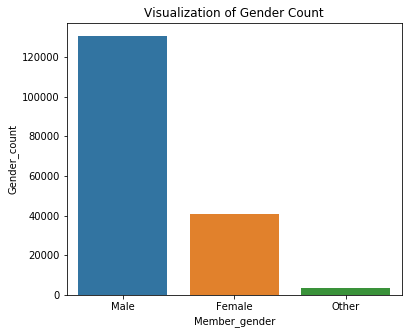

```python
#how I want the countplot to be displayed
plt.figure(figsize=[6,5])

#figure the count data plot of member_gender
gender_order=df['member_gender'].value_counts().index
ax=sns.countplot(data=df ,x='member_gender' , order=gender_order)
plt.title('Visualization of Gender Count')
ax.set(xlabel='Member_gender', ylabel='Gender_count');
```

From the visualization, I can see we had more male riders in san francisco area compared to females.

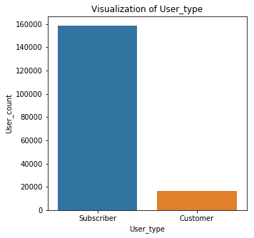

```python
#how I want the countplot to be displayed
plt.figure(figsize=[5,5])

user_order=df['user_type'].value_counts().index
#figure the countplot data of user_type
ax=sns.countplot(data=df ,x='user_type', order=user_order)
plt.title('Visualization of User_type')
ax.set(xlabel='User_type', ylabel='User_count');
```

From the analysis there are more subscribers than regular customers.Which means san francisco people like riding bikes.

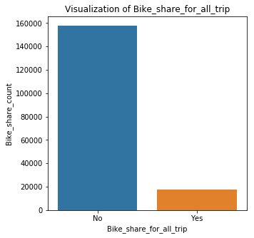

```python
#how I want the countplot to be displayed
plt.figure(figsize=[5,5])

bike_order=df['bike_share_for_all_trip'].value_counts().index

#figure the count plot of bike_share_for_all_trip
ax=sns.countplot(data=df ,x='bike_share_for_all_trip', order=bike_order)
plt.title('Visualization of Bike_share_for_all_trip')
ax.set(xlabel='Bike_share_for_all_trip', ylabel='Bike_share_count');
```

```python
# lets delete outliers with more than 60 years
df=df[df['age']<=60]

#Now lets display the max Age in the dataset
df['age'].max()
```

```
60
```

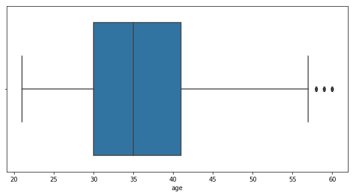

```python
#how I want the boxplot to be displayed
plt.figure(figsize=[10,5])
sns.boxplot(data=df , x='age');
```

From the analysis , most riders are between the ages of 30 to 41 years

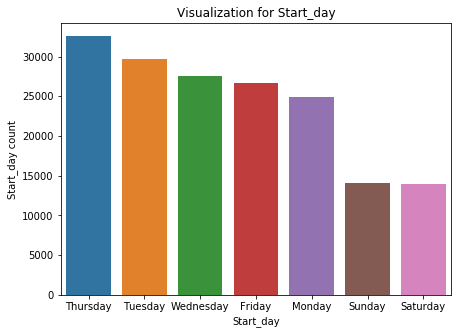

```python
#how I want the countplot to be displayed
plt.figure(figsize=[7,5])

start_order=df['start_day'].value_counts().index

#figure the count plot of member gender
ax=sns.countplot(data=df ,x='start_day', order=start_order)
plt.title('Visualization for Start_day')
ax.set(xlabel='Start_day', ylabel='Start_day count');
```

From the analysis, sundays and saturdays have the same start_day duration count

### Of the features you investigated, were there any unusual distributions? Did you perform any operations on the data to tidy, adjust, or change the form of the data? If so, why did you do this?

From the data, I converted datetime(start date and end date to day,month and year)  
I also converted duration sec to duration minutes.  
I also converted member_birth_year to age.

For unusual distribution, sundays and saturdays have the same start_day duration count.

## Bivariate Exploration

Lets explore more variables in bivariate explorations.

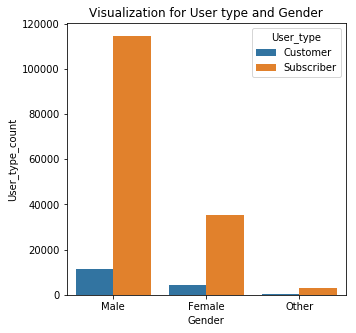

```python
#how I want the countplot to be displayed
plt.figure(figsize=[5,5])

UG_order=df['member_gender'].value_counts().index

#countplot for member gender andthe user type
sns.countplot(data=df , x='member_gender' ,hue='user_type', order=UG_order)
plt.title('Visualization for User type and Gender')
plt.xlabel('Gender')
plt.ylabel('User_type_count')
plt.legend(title='User_type');
```

from the analysis we can see we have more subscribers in each gender type

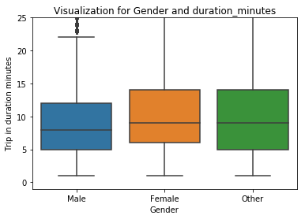

```python
#Boxplot relationship of member-gender and duration in minutes
sns.boxplot(data=df, x='member_gender', y='duration_minutes', order=gender_order)

#titles and labels for the visualization
plt.title('Visualization for Gender and duration_minutes')
plt.xlabel('Gender')
plt.ylabel('Trip in duration minutes')

#Outliers duration in figures are cut to make it clearier
plt.ylim([-1,25]);
```

From the analsyis , I can see males spent less duration in minutes compared to females and others.

```
Text(0,0.5,'Trip in duration minutes')
```

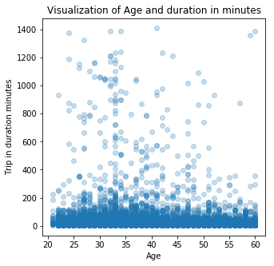

```python
#how I want the countplot to be displayed
plt.figure(figsize=[5,5])

#the scatter plot define the relationship between age an duration in minutes
ax=sns.regplot(data=df , x='age',y='duration_minutes' ,fit_reg=False ,scatter_kws ={'alpha':1/4})

#visual title and other labels
plt.title('Visualization of Age and duration in minutes')
plt.xlabel('Age')
plt.ylabel('Trip in duration minutes')
```

From the analysis, the age was less than 60 years. Majority drove between 0-200 minutes

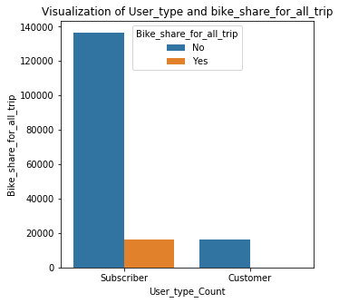

```python
#how I want the countplot to be displayed
plt.figure(figsize=[5,5])

#count plot the member gender for the user type
sns.countplot(data=df , x='user_type' ,hue='bike_share_for_all_trip', order=user_order)
plt.title('Visualization of User_type and bike_share_for_all_trip')
plt.xlabel('User_type_Count')
plt.ylabel('Bike_share_for_all_trip')
plt.legend(title='Bike_share_for_all_trip');
```

```
Text(0,0.5,'Start_hour')
```

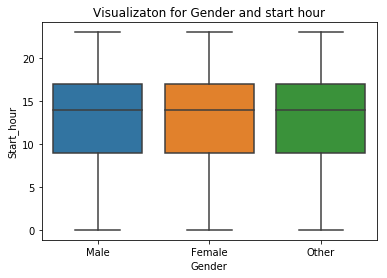

```python
#plot the relationship between the member gender and start_hour in a box plot
sns.boxplot(data=df, x='member_gender', y='start_hr', order=gender_order)

#set the titles of the figure
plt.title('Visualizaton for Gender and start hour')
plt.xlabel('Gender')
plt.ylabel('Start_hour')
```

```
Text(0,0.5,'Trip end hour')
```

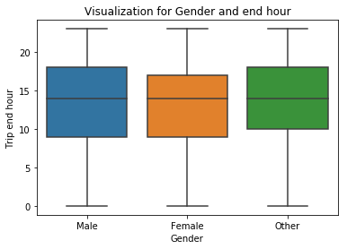

```python
#Boxplot the relationship between the member gender and end_hour
sns.boxplot(data=df, x='member_gender', y='end_hr', order=gender_order)

#Visual title and other labels
plt.title('Visualization for Gender and end hour')
plt.xlabel('Gender')
plt.ylabel('Trip end hour')
```

From the above analysis ,I can see females spent less hours to end their trip as compared to others.

### Did you observe any interesting relationships between the other features (not the main feature(s) of interest)?

From the above analysis ,I see females spent less hours to end their trip as compared to the men and others(relationship between gender and trip end hour).  
From the analysis,majority drove between 0-200 minutes and less than 60years.(relationship between age and trip duration in minutes)

## Multivariate Exploration

> Lets explore plots of three or more variables to investigate fordgobike data even further.

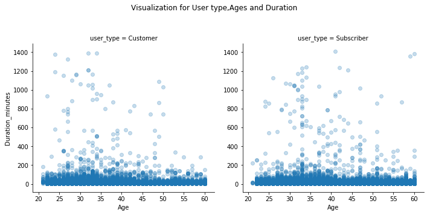

```python
#make facet grid to user_type column

ud= sns.FacetGrid(data = df, col = 'user_type', size = 5)

#scatter plotb between the age and the duration_minutes
ud.map(plt.scatter, 'age', 'duration_minutes', alpha=0.25)

#set titles and labels of the figures
ud.set_xlabels('Age')
ud.set_ylabels('Duration_minutes')

#ax.set_title('User Type,Ages and duration')
plt.subplots_adjust(top=0.8)
ud.fig.suptitle('Visualization for User type,Ages and Duration ');
```

From the analysis,customers from age 20 to 45 moved relatively at the linear duration. After 45 years, the durration in minutes dropped as compared to age 20 and 4o year.

Also subscribers also moved a relatively in linear direction from age 20 to 60

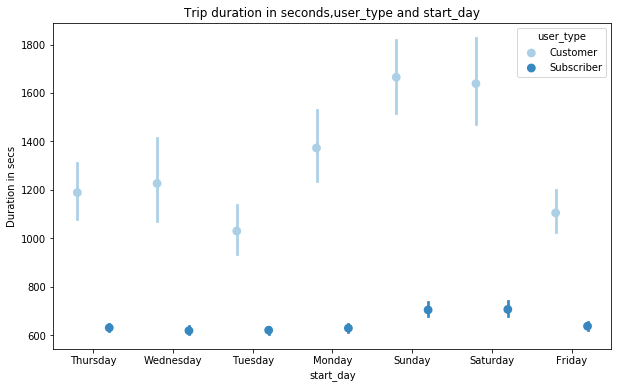

```python
#pinpoint between the start_day,duration_sec and user-type
fig = plt.figure(figsize = [10,6])
ax = sns.pointplot(data = df, x ='start_day', y = 'duration_sec', hue = 'user_type',
           palette = 'Blues', linestyles = '', dodge = 0.4,)

#set titles and labels
plt.title('Trip duration in seconds,user_type and start_day')
plt.ylabel('Duration in secs')

# plt.yscale('log')
# plt.yticks([2e3, 4e3, 6e3, 1e4], ['2k', '4k', '6k', '10k'])
ax.set_yticklabels([],minor = True)
plt.show();
```

From the analysis above, subscribers drove lesser duration between 600 and 800 seconds while customers drove more between 1000 seconds and 1800.

Also, on sunday and sunday. both customers and subscriber drove furthur duration as compared to the rest.

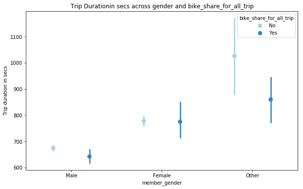

```python
#pinpoint between the member_gender,duration_sec and bike_share_for_all_trip
fig = plt.figure(figsize = [10,6])
ax = sns.pointplot(data = df, x ='member_gender', y = 'duration_sec', hue = 'bike_share_for_all_trip',
           palette = 'Blues', linestyles = '', dodge = 0.4,order=gender_order)

#set titles and labels
plt.title('Trip Durationin secs across gender and bike_share_for_all_trip')
plt.ylabel('Trip duration in secs')

# plt.yscale('log')
# plt.yticks([2e3, 4e3, 6e3, 1e4], ['2k', '4k', '6k', '10k'])
ax.set_yticklabels([],minor = True)
plt.show();
```

From the analysis, gender did not share bikes for furthur durations compared to gender who shared bikes.

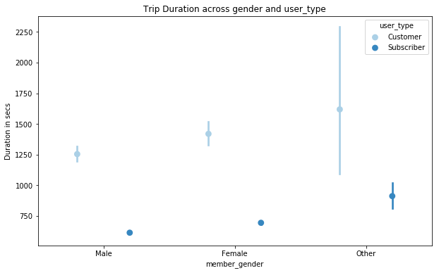

```python
#pinpoint between the member_gender,duration_sec and bike_share_for_all_trip
fig = plt.figure(figsize = [10,6])
ax = sns.pointplot(data = df, x ='member_gender', y = 'duration_sec', hue = 'user_type',
           palette = 'Blues', linestyles = '', dodge = 0.4 ,order=gender_order)

#set titles and labels
plt.title('Trip Duration across gender and user_type')
plt.ylabel('Duration in secs')

# plt.yscale('log')
# plt.yticks([2e3, 4e3, 6e3, 1e4], ['2k', '4k', '6k', '10k'])
ax.set_yticklabels([],minor = True)
plt.show();
```

From the analysis, both customers and subscribers spent less trip duration in secs as compared to female and others.

### Talk about some of the relationships you observed in this part of the investigation. Were there features that strengthened each other in terms of looking at your feature(s) of interest?

From the analysis, gender did not share bikes for furthur durations compared to gender who shared bikes.  
From the analysis, both male customers and subscribers spent less trip duration in secs as compared to female and others.

### Were there any interesting or surprising interactions between features?

From the analysis above, subscribers drove lesser duration between 600 and 800 seconds while customers drove more between 1000 seconds and 1800.

Also, on saturdays and sundays both customers and subscriber drove furthur duration as compared to the rest.I think because its weekend.

## Conclusions

In conclusion, my main interest for this analysis was to identify some patterns and make some predictions. In case any bike company wants to sell or provide bike products/activity to san francisco area, their target market should focus more of :  
Men  
Between the age of 30 to 41

Also, they like to be subscribers as compared to been a regular customer.

In general, san francisco area is a good community for any bike company to make business profits.Highly recommended.

## References

https://github.com  
https://seaborn.pydata.org/  
https://stackoverflow.com/